# MLflow_Project

```python
# Import necessray libraries
import numpy as np
import pandas as pd

import matplotlib.pyplot as plt
%matplotlib inline
import seaborn as sns

import mlflow

import warnings
warnings.filterwarnings("ignore")

from sklearn.model_selection import train_test_split
from sklearn.linear_model import LogisticRegression
from sklearn.metrics import accuracy_score, precision_score, recall_score, f1_score, roc_auc_score
```

```python
# Load dataset
df = pd.read_csv('Downloads/Loan_default.csv')
```

```python
# Get first 5 rows of dataset
df.head()
```

|  | LoanID | Age | Income | LoanAmount | CreditScore | MonthsEmployed | NumCreditLines | InterestRate | LoanTerm | DTIRatio | Education | EmploymentType | MaritalStatus | HasMortgage | HasDependents | LoanPurpose | HasCoSigner | Default |
| --- | --- | --- | --- | --- | --- | --- | --- | --- | --- | --- | --- | --- | --- | --- | --- | --- | --- | --- |
| 0 | I38PQUQS96 | 56 | 85994 | 50587 | 520 | 80 | 4 | 15.23 | 36 | 0.44 | Bachelor's | Full-time | Divorced | Yes | Yes | Other | Yes | 0 |
| 1 | HPSK72WA7R | 69 | 50432 | 124440 | 458 | 15 | 1 | 4.81 | 60 | 0.68 | Master's | Full-time | Married | No | No | Other | Yes | 0 |
| 2 | C1OZ6DPJ8Y | 46 | 84208 | 129188 | 451 | 26 | 3 | 21.17 | 24 | 0.31 | Master's | Unemployed | Divorced | Yes | Yes | Auto | No | 1 |
| 3 | V2KKSFM3UN | 32 | 31713 | 44799 | 743 | 0 | 3 | 7.07 | 24 | 0.23 | High School | Full-time | Married | No | No | Business | No | 0 |
| 4 | EY08JDHTZP | 60 | 20437 | 9139 | 633 | 8 | 4 | 6.51 | 48 | 0.73 | Bachelor's | Unemployed | Divorced | No | Yes | Auto | No | 0 |

```python
# Get column names
df.columns
```

```
Index(['LoanID', 'Age', 'Income', 'LoanAmount', 'CreditScore',
       'MonthsEmployed', 'NumCreditLines', 'InterestRate', 'LoanTerm',
       'DTIRatio', 'Education', 'EmploymentType', 'MaritalStatus',
       'HasMortgage', 'HasDependents', 'LoanPurpose', 'HasCoSigner',
       'Default'],
      dtype='object')
```

```python
# Lets create copy of dataset so that original dataset doesnt change while working on project
data = df.copy()
```

```python
data.head()
```

|  | LoanID | Age | Income | LoanAmount | CreditScore | MonthsEmployed | NumCreditLines | InterestRate | LoanTerm | DTIRatio | Education | EmploymentType | MaritalStatus | HasMortgage | HasDependents | LoanPurpose | HasCoSigner | Default |
| --- | --- | --- | --- | --- | --- | --- | --- | --- | --- | --- | --- | --- | --- | --- | --- | --- | --- | --- |
| 0 | I38PQUQS96 | 56 | 85994 | 50587 | 520 | 80 | 4 | 15.23 | 36 | 0.44 | Bachelor's | Full-time | Divorced | Yes | Yes | Other | Yes | 0 |
| 1 | HPSK72WA7R | 69 | 50432 | 124440 | 458 | 15 | 1 | 4.81 | 60 | 0.68 | Master's | Full-time | Married | No | No | Other | Yes | 0 |
| 2 | C1OZ6DPJ8Y | 46 | 84208 | 129188 | 451 | 26 | 3 | 21.17 | 24 | 0.31 | Master's | Unemployed | Divorced | Yes | Yes | Auto | No | 1 |
| 3 | V2KKSFM3UN | 32 | 31713 | 44799 | 743 | 0 | 3 | 7.07 | 24 | 0.23 | High School | Full-time | Married | No | No | Business | No | 0 |
| 4 | EY08JDHTZP | 60 | 20437 | 9139 | 633 | 8 | 4 | 6.51 | 48 | 0.73 | Bachelor's | Unemployed | Divorced | No | Yes | Auto | No | 0 |

```python
# Lets check data type of each variable
data.dtypes
```

```
LoanID             object
Age                 int64
Income              int64
LoanAmount          int64
CreditScore         int64
MonthsEmployed      int64
NumCreditLines      int64
InterestRate      float64
LoanTerm            int64
DTIRatio          float64
Education          object
EmploymentType     object
MaritalStatus      object
HasMortgage        object
HasDependents      object
LoanPurpose        object
HasCoSigner        object
Default             int64
dtype: object
```

```python
# Check number of rows and columns in dataset
rows, columns = data.shape
print('Rows:', rows)
print('Columns:', columns)
```

```
Rows: 255347
Columns: 18
```

So, we see that the data is 255347 rows, that is 255347 data points and 18 columns, that is 18 features. Out of18 features, 17 are input features and 1 is output feature.

```python
# Check for missing values
data.isnull().sum()
```

```
LoanID            0
Age               0
Income            0
LoanAmount        0
CreditScore       0
MonthsEmployed    0
NumCreditLines    0
InterestRate      0
LoanTerm          0
DTIRatio          0
Education         0
EmploymentType    0
MaritalStatus     0
HasMortgage       0
HasDependents     0
LoanPurpose       0
HasCoSigner       0
Default           0
dtype: int64
```

No missing values present in dataset

```python
# Check value counts of Target Variable
data['Default'].value_counts()
```

```
Default
0    225694
1     29653
Name: count, dtype: int64
```

```python
data['Default'].value_counts(normalize = True)
```

```
Default
0    0.883872
1    0.116128
Name: proportion, dtype: float64
```

225694(around 88%) loan applicants dont default the loan out of 255347

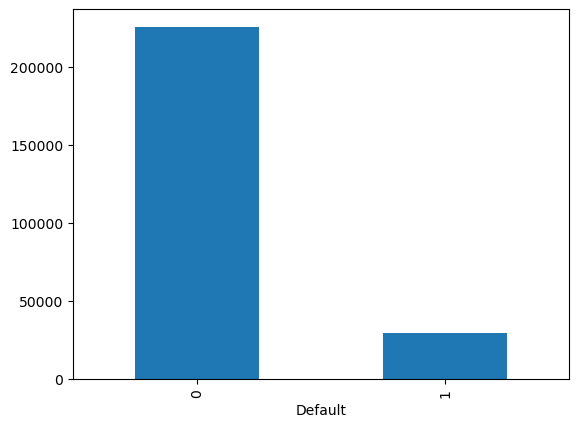

```python
# Lets visualize the target variable
data['Default'].value_counts().plot.bar()
```

More Loan Applicants has not defaulted. Data is highly imbalanced.

# EDA

Univariate Analysis

1. Categorical Variables:

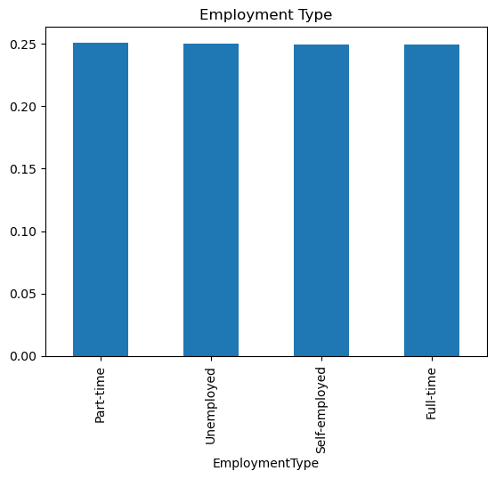

```python
data['EmploymentType'].value_counts(normalize = True).plot.bar(title = "Employment Type")
```

Count of Part-time, Unemployed, Self-employed and Full-time is almost same in dataset

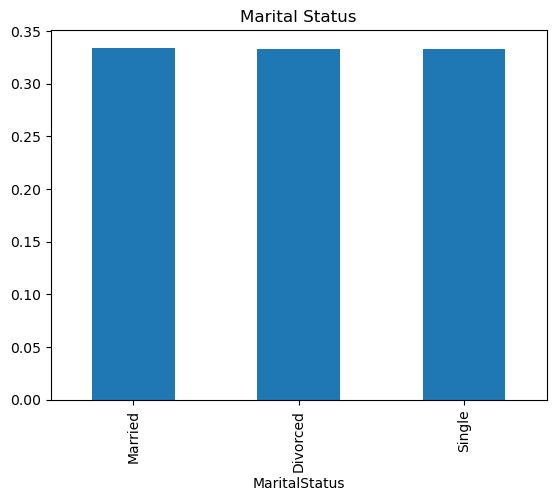

```python
data['MaritalStatus'].value_counts(normalize = True).plot.bar(title = "Marital Status")
```

Count of Married, Divorced and Single are almost same in datset

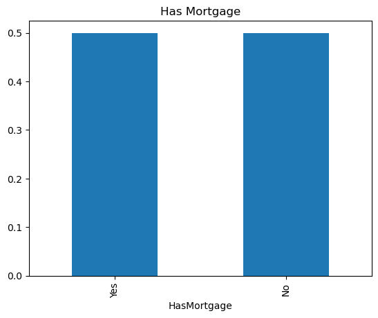

```python
data['HasMortgage'].value_counts(normalize = True).plot.bar(title = "Has Mortgage")
```

Count of Applicants with or without Mortgage is almost same

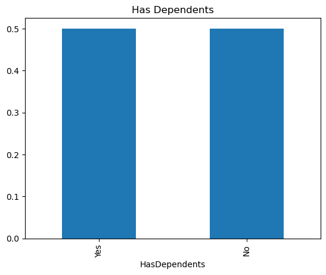

```python
data['HasDependents'].value_counts(normalize = True).plot.bar(title = "Has Dependents")
```

Count of Applicants with or without Dependents is almost same

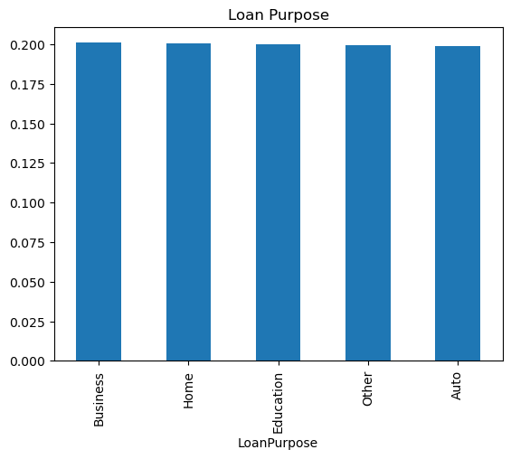

```python
data['LoanPurpose'].value_counts(normalize = True).plot.bar(title = "Loan Purpose")
```

Count of different loan purpose is almost same in dataset

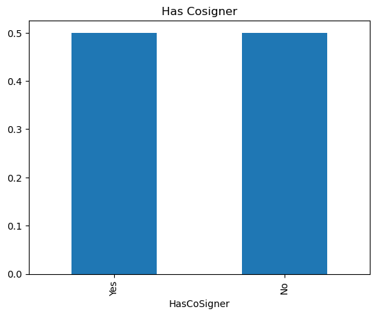

```python
data['HasCoSigner'].value_counts(normalize = True).plot.bar(title = "Has Cosigner")
```

Count of Applicants with or without Cosigner is almost same

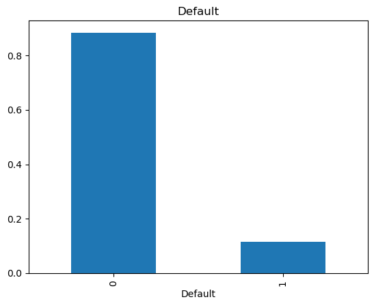

```python
data['Default'].value_counts(normalize = True).plot.bar(title = "Default")
```

Less Loan Applicants has defaulted

1. Ordinal Columns:

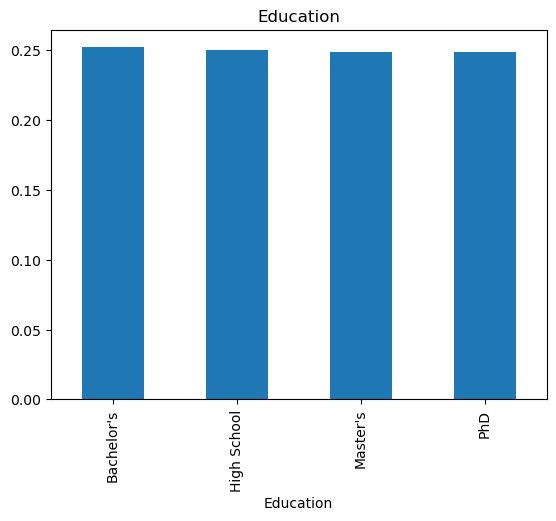

```python
data['Education'].value_counts(normalize = True).plot.bar(title = "Education")
```

Count of applicants with different Education levels is same

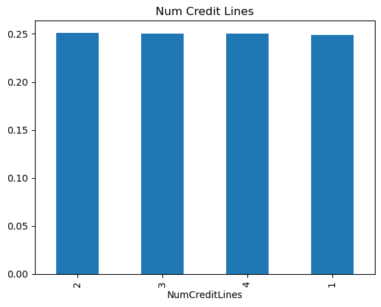

```python
data['NumCreditLines'].value_counts(normalize = True).plot.bar(title = "Num Credit Lines")
```

Count of applicants with different number of credit lines are almost same

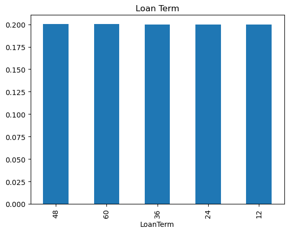

```python
data['LoanTerm'].value_counts(normalize = True).plot.bar(title = "Loan Term")
```

Count of Applicants with different years of loan term is almost same

1. Numerical Columns:

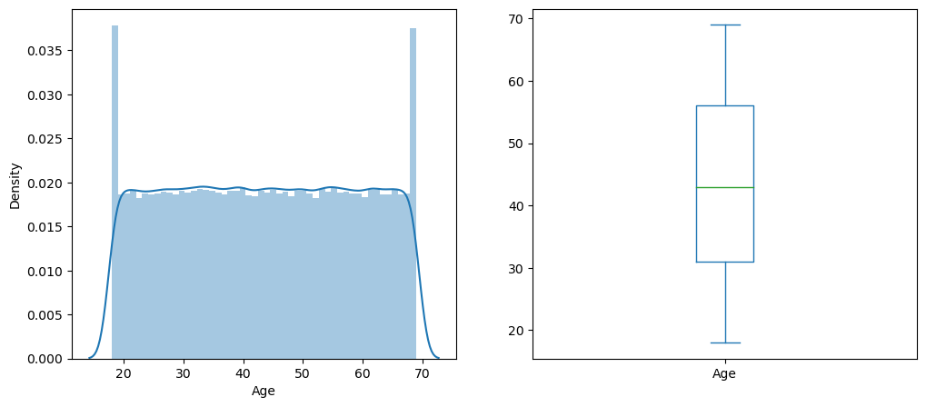

```python
plt.figure(1)
plt.subplot(121)
sns.distplot(data['Age'])
plt.subplot(122)
data['Age'].plot.box(figsize = (12,5))
plt.show()
```

There is wide range of age among applicants in the dataset mostly between 20 to 68

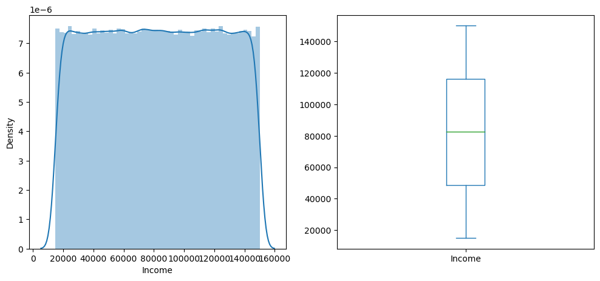

```python
plt.figure(1)
plt.subplot(121)
sns.distplot(data['Income'])
plt.subplot(122)
data['Income'].plot.box(figsize = (12,5))
plt.show()
```

There is wide range of Income among applicants in the dataset with mean income around 80000

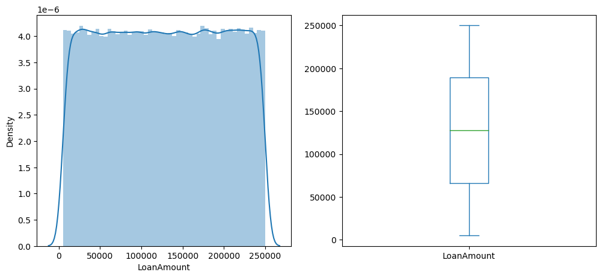

```python
plt.figure(1)
plt.subplot(121)
sns.distplot(data['LoanAmount'])
plt.subplot(122)
data['LoanAmount'].plot.box(figsize = (12,5))
plt.show()
```

Mean Loan Amount is around 125000

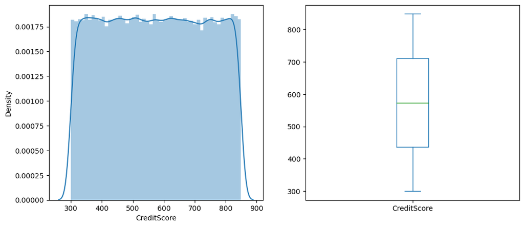

```python
plt.figure(1)
plt.subplot(121)
sns.distplot(data['CreditScore'])
plt.subplot(122)
data['CreditScore'].plot.box(figsize = (12,5))
plt.show()
```

Applicants have wide range of Credit Score

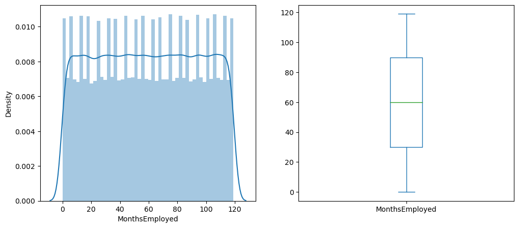

```python
plt.figure(1)
plt.subplot(121)
sns.distplot(data['MonthsEmployed'])
plt.subplot(122)
data['MonthsEmployed'].plot.box(figsize = (12,5))
plt.show()
```

Applicants have wide range of employment in months

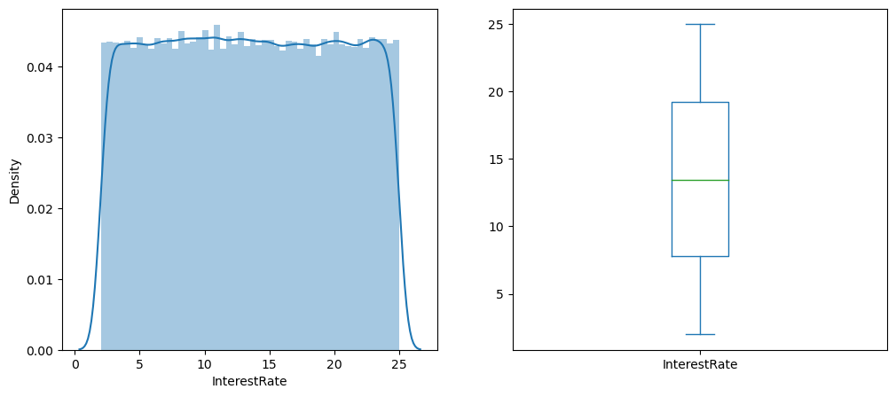

```python
plt.figure(1)
plt.subplot(121)
sns.distplot(data['InterestRate'])
plt.subplot(122)
data['InterestRate'].plot.box(figsize = (12,5))
plt.show()
```

There are different interest rates based on loan of different applicants

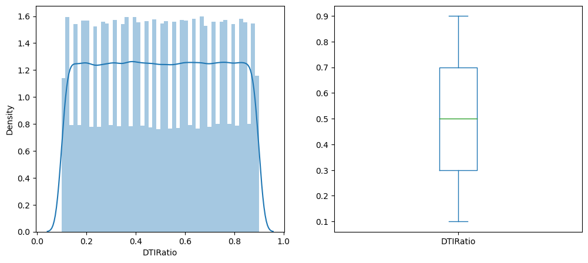

```python
plt.figure(1)
plt.subplot(121)
sns.distplot(data['DTIRatio'])
plt.subplot(122)
data['DTIRatio'].plot.box(figsize = (12,5))
plt.show()
```

Different Debt to Income ratio based on applicants

# Bivariate Analysis

Categorical Independent Variable vs Target Variable

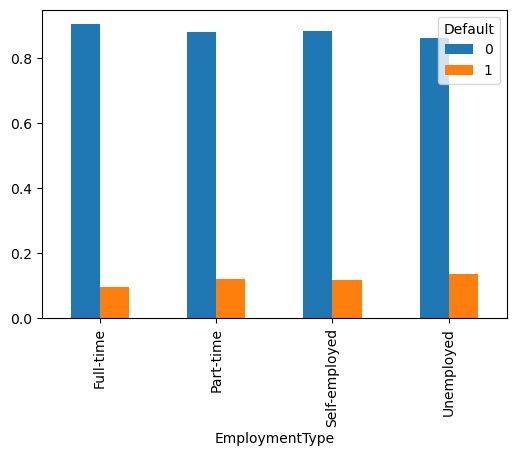

```python
EmploymentType = pd.crosstab(data['EmploymentType'], data['Default'])
EmploymentType.div(EmploymentType.sum(1).astype(float), axis = 0).plot(kind = 'bar', figsize = (6,4))
```

Unemployed are the most who defaulted the loan and Full-time employed are the most who has not defaulted the loan

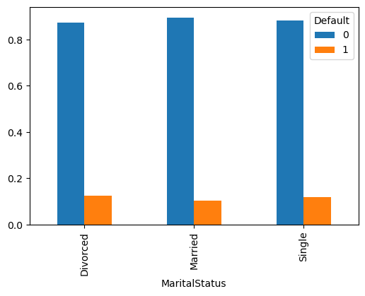

```python
MaritalStatus = pd.crosstab(data['MaritalStatus'], data['Default'])
MaritalStatus.div(MaritalStatus.sum(1).astype(float), axis = 0).plot(kind = 'bar', figsize = (6,4))
```

Married applicants are the most who has not defaulted as compare to Divorced and Single applicants

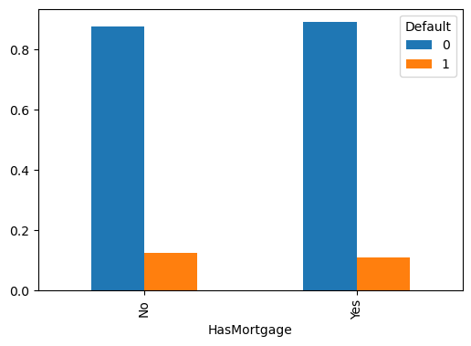

```python
HasMortgage = pd.crosstab(data['HasMortgage'], data['Default'])
HasMortgage.div(HasMortgage.sum(1).astype(float), axis = 0).plot(kind = 'bar', figsize = (6,4))
```

Applicants without mortgage has defaulted more as compare to those who have mortgage.

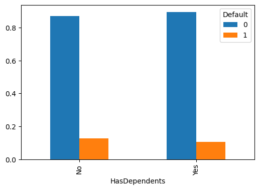

```python
HasDependents = pd.crosstab(data['HasDependents'], data['Default'])
HasDependents.div(HasDependents.sum(1).astype(float), axis = 0).plot(kind = 'bar', figsize = (6,4))
```

Applicants with no dependents has defaulted more.

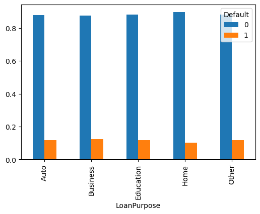

```python
LoanPurpose = pd.crosstab(data['LoanPurpose'], data['Default'])
LoanPurpose.div(LoanPurpose.sum(1).astype(float), axis = 0).plot(kind = 'bar', figsize = (6,4))
```

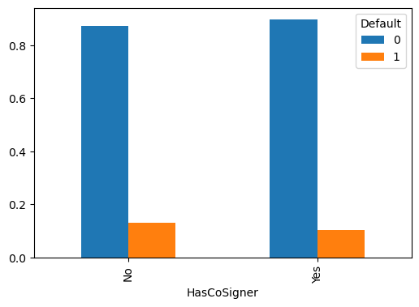

```python
HasCoSigner = pd.crosstab(data['HasCoSigner'], data['Default'])
HasCoSigner.div(HasCoSigner.sum(1).astype(float), axis = 0).plot(kind = 'bar', figsize = (6,4))
```

Applicants with no Cosigner has defaulted more

Ordinal Independent Variable vs Target Variable

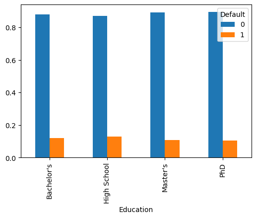

```python
Education = pd.crosstab(data['Education'], data['Default'])
Education.div(Education.sum(1).astype(float), axis = 0).plot(kind = 'bar', figsize = (6,4))
```

Applicants with High School degree has defaulted the most

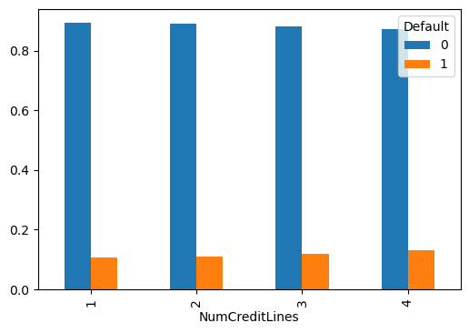

```python
NumCreditLines = pd.crosstab(data['NumCreditLines'], data['Default'])
NumCreditLines.div(NumCreditLines.sum(1).astype(float), axis = 0).plot(kind = 'bar', figsize = (6,4))
```

Applicants with Number of credit lines as 4 has defaulted more.

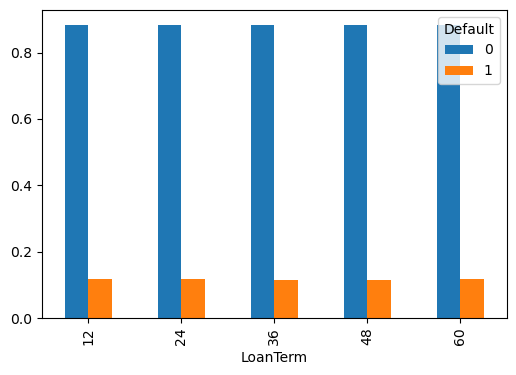

```python
LoanTerm = pd.crosstab(data['LoanTerm'], data['Default'])
LoanTerm.div(LoanTerm.sum(1).astype(float), axis = 0).plot(kind = 'bar', figsize = (6,4))
```